# Homework #3

xiwang; wolfgangwx

02/17/2019

### Load dataset

```r
data(tips, package="reshape2")
str (tips)
```

```
## 'data.frame':    244 obs. of  7 variables:
##  $ total_bill: num  17 10.3 21 23.7 24.6 ...
##  $ tip       : num  1.01 1.66 3.5 3.31 3.61 4.71 2 3.12 1.96 3.23 ...
##  $ sex       : Factor w/ 2 levels "Female","Male": 1 2 2 2 1 2 2 2 2 2 ...
##  $ smoker    : Factor w/ 2 levels "No","Yes": 1 1 1 1 1 1 1 1 1 1 ...
##  $ day       : Factor w/ 4 levels "Fri","Sat","Sun",..: 3 3 3 3 3 3 3 3 3 3 ...
##  $ time      : Factor w/ 2 levels "Dinner","Lunch": 1 1 1 1 1 1 1 1 1 1 ...
##  $ size      : int  2 3 3 2 4 4 2 4 2 2 ...
```

### Q1 How many parties did the waiter serve? Store the number in numParty and print.

```r
numParty <- length (tips$size)
numParty
```

```
## [1] 244
```

### Q2 What are the types of variables in the data frame tips?

##### Three types of variabels are contained in the data frame including number, factor, and integer.

```r
str (tips)
```

```
## 'data.frame':    244 obs. of  7 variables:
##  $ total_bill: num  17 10.3 21 23.7 24.6 ...
##  $ tip       : num  1.01 1.66 3.5 3.31 3.61 4.71 2 3.12 1.96 3.23 ...
##  $ sex       : Factor w/ 2 levels "Female","Male": 1 2 2 2 1 2 2 2 2 2 ...
##  $ smoker    : Factor w/ 2 levels "No","Yes": 1 1 1 1 1 1 1 1 1 1 ...
##  $ day       : Factor w/ 4 levels "Fri","Sat","Sun",..: 3 3 3 3 3 3 3 3 3 3 ...
##  $ time      : Factor w/ 2 levels "Dinner","Lunch": 1 1 1 1 1 1 1 1 1 1 ...
##  $ size      : int  2 3 3 2 4 4 2 4 2 2 ...
```

### Q3 Create a vector named day containing the day of visits in tips. The factor levels should be ordered from Thursday to Sunday. Also print the variable.

```r
levels(tips$day)=c("Thur","Fri","Sat","Sun")
tips$day <- sort(tips$day)
tips
```

```
##     total_bill   tip    sex smoker  day   time size
## 1        16.99  1.01 Female     No Thur Dinner    2
## 2        10.34  1.66   Male     No Thur Dinner    3
## 3        21.01  3.50   Male     No Thur Dinner    3
## 4        23.68  3.31   Male     No Thur Dinner    2
## 5        24.59  3.61 Female     No Thur Dinner    4
## 6        25.29  4.71   Male     No Thur Dinner    4
## 7         8.77  2.00   Male     No Thur Dinner    2
## 8        26.88  3.12   Male     No Thur Dinner    4
## 9        15.04  1.96   Male     No Thur Dinner    2
## 10       14.78  3.23   Male     No Thur Dinner    2
## 11       10.27  1.71   Male     No Thur Dinner    2
## 12       35.26  5.00 Female     No Thur Dinner    4
## 13       15.42  1.57   Male     No Thur Dinner    2
## 14       18.43  3.00   Male     No Thur Dinner    4
```

[output cut: 230 more lines]

### Q4 Create a data frame named female5 containing the meal paid by a female payer in a party with size greater than or euqal to 5. Also print the data frame.

```r
female5 <- subset(tips, sex == "Female" & size >= 5)
dim (female5)
```

```
## [1] 3 7
```

```r
female5
```

```
##     total_bill  tip    sex smoker day   time size
## 126      29.80 4.20 Female     No Sat  Lunch    6
## 144      27.05 5.00 Female     No Sat  Lunch    6
## 156      29.85 5.14 Female     No Sat Dinner    5
```

### Q5 How does the tipping amount (tip) depend on the overall bill (total_bill)? Describe the relationship in words. Describe at least two types of anomalies in the plot. What do they mean? Use the ggplot2 package to make a chart.

##### According to the plot, a positive relationship between total bill and tips can be identified in this dataset.

##### Anomalies also can be identified that some people pay a large amout of tips with a small bill, but some people apay a small tips with a large bill.

##### And most of the tips are not exceed $6, no matter how much of the bill.

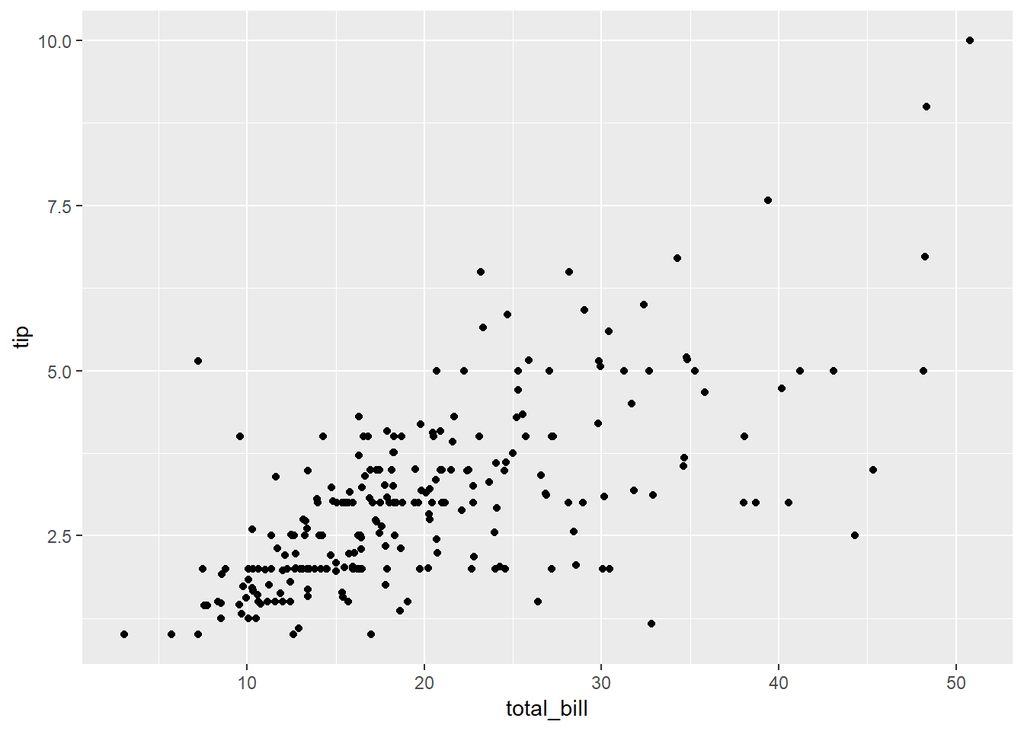

```r
library (ggplot2)
ggplot (data=tips, aes(x=total_bill, y=tip)) + geom_point()
```

### Q6 Introduce a variable tiprate into the data set, that incorporates the rate of tips. What is the average rate for tips?

##### The average rate of tips is 0.1608.

```r
head (tips)
```

```
##   total_bill  tip    sex smoker  day   time size
## 1      16.99 1.01 Female     No Thur Dinner    2
## 2      10.34 1.66   Male     No Thur Dinner    3
## 3      21.01 3.50   Male     No Thur Dinner    3
## 4      23.68 3.31   Male     No Thur Dinner    2
## 5      24.59 3.61 Female     No Thur Dinner    4
## 6      25.29 4.71   Male     No Thur Dinner    4
```

```r
tips$tiprate <-  tips$tip/tips$total_bill
mean (tips$tiprate)
```

```
## [1] 0.1608026
```

### Q7 Make a boxplot of the tip rate by time. The x-axis should be ordered by lunch and then dinner. Use the ggplot2 package to make a chart.

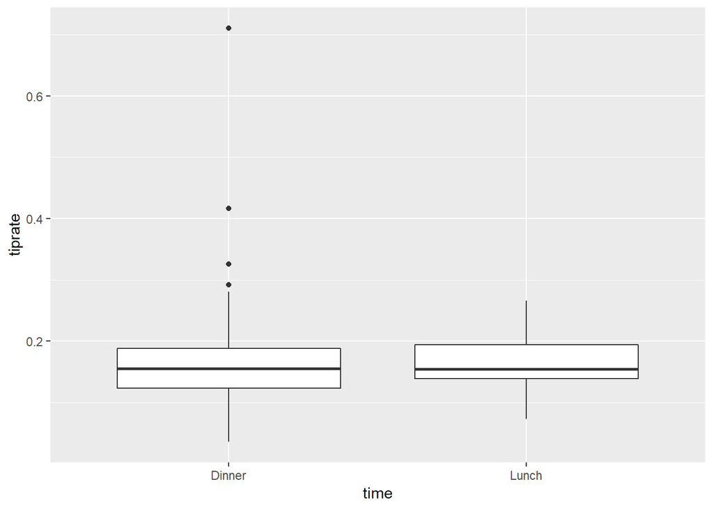

```r
ggplot (tips, aes(x=time, y=tiprate)) + geom_boxplot()
```

### Q8 How does smoking behavior and gender of the person who pays impact the relationship between tip and total bill? Find a visualization that incorporates all four variables. Interpret the result.

##### Both the relationship between tip and total bill is positive no matter of female and male, however, there are more male customer who pay a large bill with more than $40 and also leave a large amount of tips.

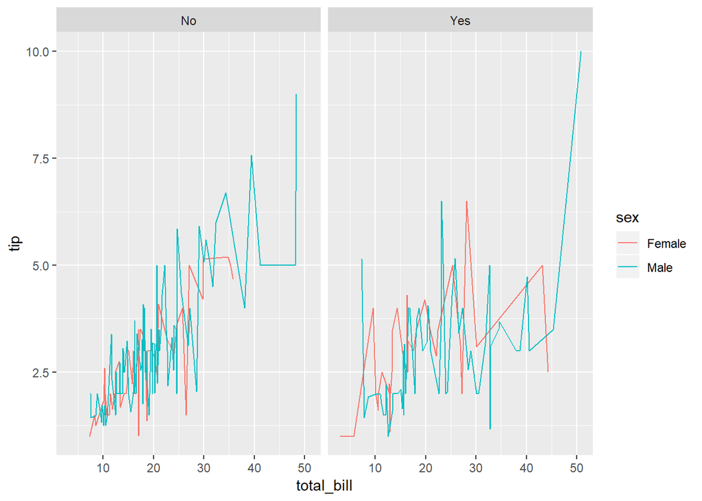

```r
ggplot (tips, aes(x=total_bill, y=tip, color=sex)) + geom_line() + facet_wrap(~smoker, ncol=10)
```

### Q9 Use ggplot2 to find a graphical summary of the relationship between day of the week and gender of the person paying the bill. What can you say about this relationship?

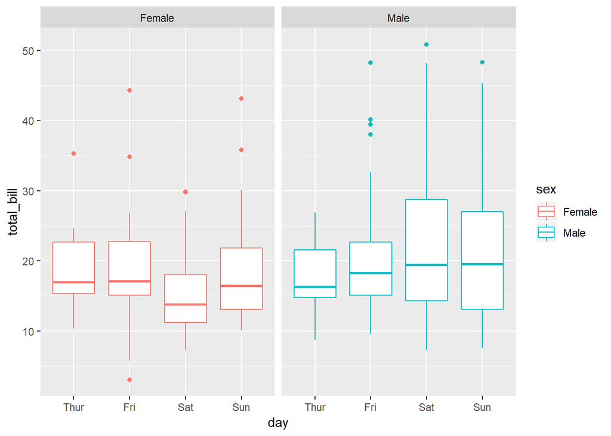

```r
ggplot (tips, aes(x=day, y=total_bill, color=sex)) + geom_boxplot() + facet_wrap(~sex, ncol=10)
```